# Problem Set 2

Ramsey EL Lethy

2025-02-05

## Question 1

For each of parts (a) through (d), indicate whether we would generally expect the per- formance of a flexible statistical learning method to be better or worse than an inflexible method. Justify your answer.

1. The sample size n is extremely large, and the number of predictors p is small.

More flexible models can have higher performance but they need a large traning set, so in this case, a more flexible model would be ideal.

2. The number of predictors p is extremely large, and the number of observations n is small.

A more flexible model needs a large dataset, so in this case a less flexible method would be more ideal. When there are more predictors than training data, the model is likely to overfit because of lots of noise.

3. The relationship between the predictors and response is highly non-linear.

a less flexible learning method needs as close to a linear relationship as possible for accuracy. You might not even learn anything while trying to predict using a non-linear dataset. In this case, a more flexible, non-parametric model, that can adapt to more intricate relationships, would perform better.

4. The variance of the error terms, Var(), is extremely high.

less flexible method because the accuracy due to noise is surely going to be very low for the more flexible model. A regression, for example, can do a good job at reducing the variance.

## Question 2

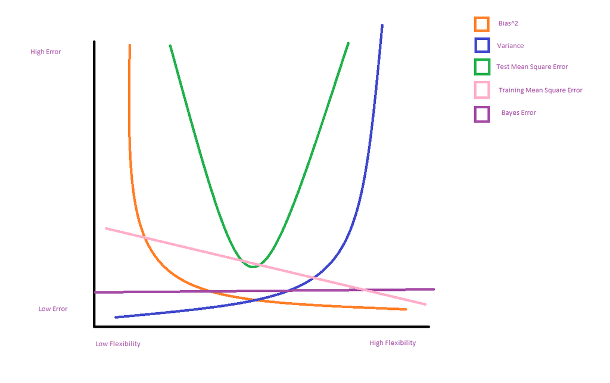

Bias Variance Composition

Bias^2 starts high and decreases as you increase flexibility, less flexible models make hardcore assumptions about the data, so there are biases to be introcuded as you increace the flexibility of your mdoel, you can reduce bias by capturing pattterns better.

Error in variance increases as you incerease flexibility. A higher flexibility model fine tune to the data a lot closer than a less flexible, so small variations in the data are personified greatly. Because less flexible models make more generalizations, they have lower variance.

Test Mean Square Error follows a u shape curve because increased flexibility lowers bias until after a point, too much flexibility causes the model to over fit. Which can increase test error.

Training Mean Square Error initially starts higher and decreases linearly, more flexible models fit the training data better, leading to lower training error.

Bayes Error is a constant error that cannot be eliminated with any model, this is noise because of real world observations.

## Question 3

```r
library(class)
data <- data.frame(
  Obs = c(1, 2, 3, 4, 5, 6),
  X1 = c(0, 2, 0, 0, -1, 1),
  X2 = c(3, 0, 1, 1, 0, 1),
  X3 = c(0, 0, 3, 2, 1, 1),
  Y = factor(c("Red", "Red", "Red", "Green", "Green", "Red"))
)

test_point <- c(0, 0, 0)

data$Distance <- apply(data[, c("X1", "X2", "X3")], 1, function(row) {
  dist(rbind(row, test_point))
})

print(data)
```

```
##   Obs X1 X2 X3     Y Distance
## 1   1  0  3  0   Red 3.000000
## 2   2  2  0  0   Red 2.000000
## 3   3  0  1  3   Red 3.162278
## 4   4  0  1  2 Green 2.236068
## 5   5 -1  0  1 Green 1.414214
## 6   6  1  1  1   Red 1.732051
```

```r
prediction <- knn(train = data[, c("X1", "X2", "X3")],
                  test = matrix(test_point, nrow = 1),
                  cl = data$Y, k = 1)

print(paste("Prediction with K = 1:", prediction))
```

```
## [1] "Prediction with K = 1: Green"
```

```r
predictionK3 <- knn(train = data[, c("X1", "X2", "X3")],
                  test = matrix(test_point, nrow = 1),
                  cl = data$Y, k = 3)

print(paste("Prediction with K = 3:", predictionK3))
```

```
## [1] "Prediction with K = 3: Red"
```

With K = 1,

the KNN algirthm only consideres the nearest neighbor. So for this case, the nearest neighbor is the observation with the euclidian distance closest to (0,0,0). Looking at our distances, we see that green has the smallest distance,

With K = 3

We are now taking into account the 3 nearest points closest to 0, based on the distances we calculated, 2/3 nearest neighbors are red, so they take a majority.

We can expect the best value for K to be small because a small K is better for non-linear decision boundaries because it lets the KNN capture local patterns, which is really important for accurate classfication.

## Question 4

With a very flexible approach, we can fit the training data very closely, we can achieve a lower training error than that of a more flexible approach. This can help us capture these non-linear relationships between our target and the rest of the data.

The problem with this approach is that the model might overfit the training data, it takes in the noise from the training data and actually attributes it to the model rather than the real patterns. Another problem is that we need a really large dataset to capture these relationships accurately. Otherwise, there will be poor generalizations from our model

Its best to use this approach when the relationship between the features and the target is not linear. Its also important that you have a large traning data set. In cases where we have a linear relationship between the target and features, or small traning data, we’d use the less flexible model

## Question 5

Parametric approaches make assumptions about the form of the relationship between features and the target. The best exmample is how a linear regression assumes that there is a linear relationship between X and Y.

A non parametric approach does not make as strong assumptions about the function of the target and features, as the data grows, we can increase the number of parameters

Parametric approaches are nice because they are simple and easy to interpret. They give a good baseline understanding of what we’re looking at, it also requires less data, so we can generally be more efficent with our approach

Parametric approaches have limited flexibiliy, those non linear relationships are lost in the wind when we use a model like that. If the model is assumed to be some function and its not, its basically useless.